# NOM: KRAH

# PRENOMS: KOUAME DAMTY ABRAHAM

## DU BIG DATA, DATA SCIENCE ET ANALYSE DES RISQUES SOUS PYTHON

## PROJET TUTEURE RESEAUX DE NEURONES

## INTRODUCTION

Dans le domaine de la finance, la prévision des cours des actions est une tâche cruciale pour les investisseurs et les analystes. Avec l'essor des techniques de machine learning et des réseaux de neurones, il est devenu possible d'analyser de grandes quantités de données financières pour prédire les tendances du marché et prendre des décisions d'investissement éclairées. Ce projet vise à exploiter ces technologies avancées pour prédire les cours des actions et simuler des stratégies de trading.

Ce projet se concentre sur la récupération des cours de clôture d'une liste d'actions à partir de Yahoo Finance, couvrant la période du 1er janvier 2021 au 31 décembre 2022. Ces données seront stockées dans une base de données pour une analyse ultérieure. Ensuite, un réseau de neurones sera entraîné sur les données de la période du 1er janvier 2021 au 31 août 2022 pour prédire les cours des actions, ou le sens de leur évolution, pour la période du 1er septembre 2022 au 31 décembre 2022.

Enfin, une simulation de trading sera réalisée pour chaque action, en partant d'un capital initial de 1 million d'euros par action au 1er septembre 2022, en prenant en compte des frais de courtage de 0.01€. Les résultats de ces simulations seront générés sous forme de fichiers CSV, fournissant une analyse détaillée des performances des stratégies de trading basées sur les prévisions des réseaux de neurones.

```python
import pandas as pd

# Créer un DataFrame avec les tickers des actions
data = {'Ticker': ['AAPL','AMZN', 'TSLA']}
actions_df = pd.DataFrame(data)

# Enregistrer le DataFrame dans un fichier CSV
actions_df.to_csv('actions.csv', index=False)
```

```python
import yfinance as yf
import pandas as pd

# Charger la liste des actions depuis un fichier CSV
actions_df = pd.read_csv('actions.csv')

# Définir les dates de début et de fin pour l'entraînement et la prédiction
start_date_train = '2021-01-01'
end_date_train = '2022-08-31'
start_date_predict = '2022-09-01'
end_date_predict = '2022-12-31'

# Fonction pour récupérer les données de clôture
def get_stock_data(ticker, start_date, end_date):
    stock = yf.Ticker(ticker)
    return stock.history(start=start_date, end=end_date)['Close']

# Récupérer les données pour chaque action pour la période d'entraînement
data_train = {}
for ticker in actions_df['Ticker']:
    data_train[ticker] = get_stock_data(ticker, start_date_train, end_date_train)

# Récupérer les données pour chaque action pour la période de prédiction
data_predict = {}
for ticker in actions_df['Ticker']:
    data_predict[ticker] = get_stock_data(ticker, start_date_predict, end_date_predict)

# Convertir les données en DataFrames
stocks_train_df = pd.DataFrame(data_train)
stocks_predict_df = pd.DataFrame(data_predict)

# Enregistrer les données dans des fichiers CSV
stocks_train_df.to_csv('stocks_train.csv', index=True)
stocks_predict_df.to_csv('stocks_predict.csv', index=True)
```

## Analyse Exploratoire des Données (EDA)

L'analyse exploratoire des données (EDA) permet de comprendre la structure des données, d'identifier les tendances et les anomalies, et de préparer les données pour la modélisation. Cette section fournit une analyse détaillée des données de prix de clôture des actions AAPL, AMZN, et TSLA pour les périodes d'entraînement et de prédiction.

#### 1. Statistiques Descriptives

##### Données d'Entraînement (01/01/2021 - 31/08/2022)

Les statistiques descriptives des données d'entraînement révèlent les caractéristiques principales des prix de clôture des actions sur cette période :

- **AAPL** :
  - **Nombre d'observations** : 418
  - **Prix moyen** : 146.21
  - **Écart-type** : 16.64
  - **Minimum** : 114.21
  - **Maximum** : 179.48
- **AMZN** :
  - **Nombre d'observations** : 418
  - **Prix moyen** : 155.13
  - **Écart-type** : 20.47
  - **Minimum** : 102.31
  - **Maximum** : 186.57
- **TSLA** :
  - **Nombre d'observations** : 418
  - **Prix moyen** : 271.02
  - **Écart-type** : 51.40
  - **Minimum** : 187.67
  - **Maximum** : 409.97

Ces statistiques montrent que TSLA a la plus grande volatilité avec un écart-type élevé et un large éventail de valeurs, tandis que AAPL et AMZN montrent des fluctuations moins prononcées.

##### Données de Prédiction (01/09/2022 - 31/12/2022)

Pour la période de prédiction, les statistiques descriptives sont les suivantes :

- **AAPL** :
  - **Nombre d'observations** : 84
  - **Prix moyen** : 144.11
  - **Écart-type** : 7.59
  - **Minimum** : 125.01
  - **Maximum** : 161.83
- **AMZN** :
  - **Nombre d'observations** : 84
  - **Prix moyen** : 104.89
  - **Écart-type** : 15.36
  - **Minimum** : 81.82
  - **Maximum** : 136.45
- **TSLA** :
  - **Nombre d'observations** : 84
  - **Prix moyen** : 214.19
  - **Écart-type** : 53.10
  - **Minimum** : 109.10
  - **Maximum** : 309.07

Les données de prédiction montrent également une volatilité élevée pour TSLA, similaire à celle observée pendant la période d'entraînement.

#### 2. Visualisation des Tendances

Les graphiques ci-dessous montrent les tendances des prix de clôture des actions pour les périodes d'entraînement et de prédiction.

##### Graphique des Prix de Clôture des Actions pour l'Entraînement

Le graphique des prix de clôture pour la période d'entraînement (01/01/2021 - 31/08/2022) révèle plusieurs tendances importantes :

##### Graphique des Prix de Clôture des Actions pour la Prédiction

Le graphique des prix de clôture pour la période de prédiction (01/09/2022 - 31/12/2022) révèle les tendances suivantes :

- **AAPL** : Les prix ont montré une baisse générale avec des fluctuations régulières, possiblement en réponse aux préoccupations macroéconomiques, telles que l'inflation et la hausse des taux d'intérêt, qui ont affecté le sentiment des investisseurs.
- **AMZN** : Les prix ont montré une baisse significative avec une tendance plus linéaire, peut-être en raison d'une correction de marché après une forte croissance pendant la pandémie et des préoccupations concernant les coûts croissants et les problèmes de chaîne d'approvisionnement.
- **TSLA** : Les prix ont continué à montrer une forte volatilité avec une tendance globale à la baisse, indiquant des préoccupations spécifiques au secteur automobile, y compris les problèmes de production et de chaîne d'approvisionnement, ainsi que la concurrence accrue dans le marché des véhicules électriques.

L'analyse exploratoire des données révèle des tendances distinctes et des niveaux de volatilité différents pour chaque action. Les actions TSLA montrent la plus grande volatilité, tandis que les actions AAPL et AMZN montrent des tendances plus modérées mais cohérentes. Ces insights sont essentiels pour la modélisation et les prédictions futures.

Les prochaines étapes consisteront à préparer les données pour la modélisation, choisir des modèles appropriés comme LSTM , et effectuer des prédictions et des simulations de trading basées sur ces modèles.

```
Statistiques descriptives pour les données d'entraînement
             AAPL        AMZN        TSLA
count  418.000000  418.000000  418.000000
mean   146.205411  155.133989  271.024593
std     16.639557   20.470209   51.397270
min    114.210663  102.309998  187.666672
25%    131.756130  146.954754  230.397503
50%    145.409874  161.621498  260.314987
75%    160.689808  169.001877  302.764160
max    179.481125  186.570496  409.970001

Statistiques descriptives pour la période de prédiction
             AAPL        AMZN        TSLA
count   84.000000   84.000000   84.000000
mean   144.114822  104.889881  214.190596
std      7.590472   15.360101   53.095676
min    125.010117   81.820000  109.099998
25%    138.960285   91.002502  180.097504
50%    144.814743  101.615002  212.845001
75%    149.339912  117.484999  253.392502
max    161.826157  136.449997  309.070007
```

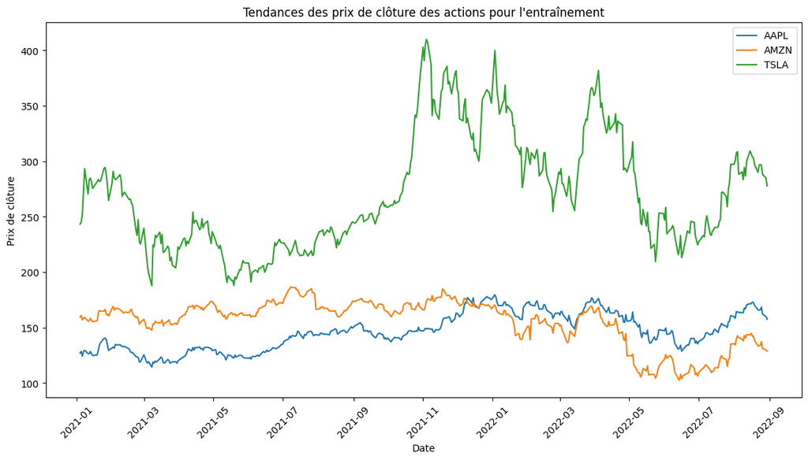

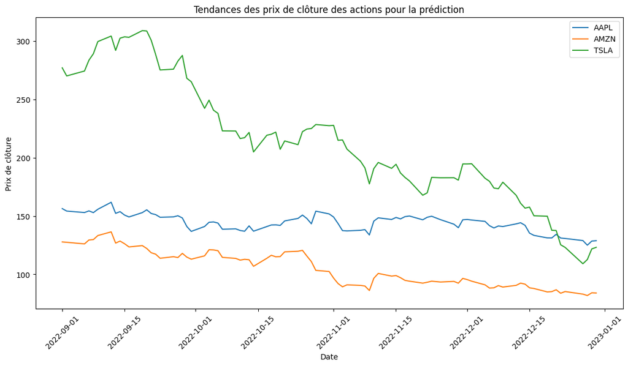

```python
import matplotlib.pyplot as plt
import seaborn as sns

# Charger les données
stocks_train_df = pd.read_csv('stocks_train.csv', index_col=0, parse_dates=True)
stocks_predict_df = pd.read_csv('stocks_predict.csv', index_col=0, parse_dates=True)

# Afficher les statistiques descriptives
print("Statistiques descriptives pour les données d'entraînement")
print(stocks_train_df.describe())

print("\nStatistiques descriptives pour la période de prédiction")
print(stocks_predict_df.describe())

# Visualiser les tendances des prix de clôture
plt.figure(figsize=(14, 7))
for column in stocks_train_df.columns:
    plt.plot(stocks_train_df.index, stocks_train_df[column], label=column)
plt.title('Tendances des prix de clôture des actions pour l\'entraînement')
plt.xlabel('Date')
plt.ylabel('Prix de clôture')
plt.legend()
plt.xticks(rotation=45)
plt.show()

plt.figure(figsize=(14, 7))
for column in stocks_predict_df.columns:
    plt.plot(stocks_predict_df.index, stocks_predict_df[column], label=column)
plt.title("Tendances des prix de clôture des actions pour la prédiction")
plt.xlabel('Date')
plt.ylabel('Prix de clôture')
plt.legend()
plt.xticks(rotation=45)
plt.show()
```

## Analyse de la Stationnarité

#### Concept de Stationnarité

La stationnarité d'une série temporelle signifie que ses propriétés statistiques, telles que la moyenne et la variance, restent constantes au fil du temps. Cette condition est cruciale pour de nombreux modèles de séries temporelles traditionnels, comme les modèles ARIMA, qui nécessitent des séries stationnaires pour garantir la stabilité des relations entre les variables.

Pour tester la stationnarité des séries temporelles des prix de clôture des actions AAPL, AMZN et TSLA, nous avons utilisé le test de Dickey-Fuller augmenté (ADF). Ce test vérifie l'hypothèse nulle selon laquelle une unité racine est présente dans la série temporelle, ce qui signifie que la série est non stationnaire.

#### Résultats du Test de Dickey-Fuller

Les résultats des tests de stationnarité pour les actions AAPL, AMZN et TSLA sont les suivants :

##### Test de stationnarité pour AAPL

```
plaintext
Test Statistic                  -1.784470
p-value                          0.388199
#Lags Used                       0.000000
Number of Observations Used    417.000000
Critical Value (1%)             -3.446129
Critical Value (5%)             -2.868496
Critical Value (10%)            -2.570475
```

##### Test de stationnarité pour AMZN

```
plaintext
Test Statistic                  -1.450290
p-value                          0.557943
#Lags Used                       0.000000
Number of Observations Used    417.000000
Critical Value (1%)             -3.446129
Critical Value (5%)             -2.868496
Critical Value (10%)            -2.570475
```

##### Test de stationnarité pour TSLA

[output not shown]

#### Interprétation des Résultats

Pour chaque action, les statistiques de test sont supérieures aux valeurs critiques aux niveaux de 1%, 5% et 10%. De plus, les p-values sont toutes supérieures à 0.05, ce qui signifie que nous ne pouvons pas rejeter l'hypothèse nulle de non-stationnarité. Par conséquent, les séries temporelles des prix de clôture des actions AAPL, AMZN et TSLA sont non stationnaires.

#### Traitement des Séries Non Stationnaires

Pour les modèles traditionnels de séries temporelles comme GARCH ou ARIMA, il est crucial de rendre les séries stationnaires avant de procéder à la modélisation. Cela peut être fait en différenciant la série. Cependant, pour les modèles de deep learning tels que les LSTM (Long Short-Term Memory) et les GRU (Gated Recurrent Unit), il n'est pas nécessaire de rendre les séries stationnaires. Ces modèles sont capables de capturer les dépendances temporelles et de modéliser des séries non stationnaires de manière efficace.

### Modèles GARCH

Les modèles GARCH (Generalized Autoregressive Conditional Heteroskedasticity) sont utilisés pour modéliser la volatilité des séries temporelles financières. Ils capturent la persistance et les variations de la volatilité en modélisant la variance conditionnelle des erreurs. Contrairement aux modèles ARIMA, qui se concentrent sur la moyenne de la série temporelle, les modèles GARCH se concentrent sur la modélisation de la volatilité.

Les modèles GARCH sont particulièrement adaptés pour les données financières en raison de leur capacité à capturer les dynamiques complexes de la volatilité. Cependant, pour ce projet, nous privilégierons l'utilisation de réseaux de neurones.

## Modèles de Deep Learning

#### LSTM (Long Short-Term Memory)

Les LSTM sont une classe de réseaux de neurones récurrents (RNN) conçus pour modéliser les dépendances à long terme dans les séries temporelles. Ils utilisent des cellules mémoire pour conserver l'information sur de longues périodes, ce qui leur permet de surmonter le problème du gradient qui disparaît rencontré par les RNN classiques. Les LSTM sont particulièrement adaptés pour les données financières en raison de leur capacité à gérer des séries temporelles non stationnaires et volatiles.

#### GRU (Gated Recurrent Unit)

Les GRU sont une variante des LSTM avec une architecture plus simple. Ils utilisent des portes pour contrôler le flux d'information et ont tendance à être plus rapides à entraîner tout en offrant des performances comparables aux LSTM. Les GRU sont également bien adaptés pour modéliser les séries temporelles financières.

Bien que les modèles GARCH soient efficaces pour modéliser la volatilité, les réseaux de neurones tels que les LSTM et GRU sont mieux adaptés pour capturer les dépendances temporelles complexes présentes dans les données financières non stationnaires. Pour ce projet, nous utiliserons principalement les modèles LSTM et GRU pour prédire les cours des actions, car ils sont capables de gérer efficacement les séries temporelles non stationnaires et de fournir des prédictions précises pour la simulation de stratégies de trading.

```python
import pandas as pd
import yfinance as yf
from statsmodels.tsa.stattools import adfuller
# Charger les données
stocks_train_df = pd.read_csv('stocks_train.csv', index_col=0, parse_dates=True)

# Fonction pour le test de stationnarité
def test_stationarity(timeseries):
    print('Results of Dickey-Fuller Test:')
    dftest = adfuller(timeseries, autolag='AIC')
    dfoutput = pd.Series(dftest[0:4], index=['Test Statistic','p-value','#Lags Used','Number of Observations Used'])
    for key, value in dftest[4].items():
        dfoutput['Critical Value (%s)' % key] = value
    print(dfoutput)

# Tester la stationnarité de chaque série temporelle
for column in stocks_train_df.columns:
    print(f"\nTest de stationnarité pour {column}")
    test_stationarity(stocks_train_df[column])
```

```
Test de stationnarité pour AAPL
Results of Dickey-Fuller Test:
Test Statistic                  -1.784469
p-value                          0.388199
#Lags Used                       0.000000
Number of Observations Used    417.000000
Critical Value (1%)             -3.446129
Critical Value (5%)             -2.868496
Critical Value (10%)            -2.570475
dtype: float64

Test de stationnarité pour AMZN
Results of Dickey-Fuller Test:
Test Statistic                  -1.450290
p-value                          0.557943
#Lags Used                       0.000000
Number of Observations Used    417.000000
Critical Value (1%)             -3.446129
Critical Value (5%)             -2.868496
Critical Value (10%)            -2.570475
dtype: float64

Test de stationnarité pour TSLA
Results of Dickey-Fuller Test:
Test Statistic                  -2.163044
p-value                          0.219931
#Lags Used                       0.000000
Number of Observations Used    417.000000
Critical Value (1%)             -3.446129
Critical Value (5%)             -2.868496
Critical Value (10%)            -2.570475
dtype: float64
```

## Modélisation avec LSTM

Dans cette section, nous avons entraîné un modèle de réseau de neurones LSTM (Long Short-Term Memory) pour prédire les prix de clôture des actions AAPL, AMZN, et TSLA. Voici une explication détaillée du processus :

#### Préparation des Données

1. **Normalisation des Données** :
   - Les données de prix de clôture pour chaque action sont normalisées dans une plage de [0, 1] en utilisant `MinMaxScaler`. Cela aide le modèle à converger plus rapidement et améliore la stabilité de l'entraînement.
2. **Création des Ensembles de Données** :
   - La fonction de création des ensembles de données transforme les données normalisées en séquences pour l'entraînement. Chaque séquence de longueur `look_back` (ici 60 jours) est utilisée pour prédire la valeur suivante. Cette méthode permet au modèle de capturer les tendances et les dépendances temporelles à long terme.

#### Construction et Entraînement du Modèle LSTM

Pour chaque action (AAPL, AMZN, TSLA), les étapes suivantes ont été suivies :

1. **Extraction et Normalisation des Données** :
   - Les données de prix de clôture pour chaque action sont extraites et normalisées individuellement.
2. **Création des Ensembles de Données** :
   - Les données normalisées sont transformées en ensembles de séquences de longueur `look_back` pour l'entraînement du modèle.
3. **Construction du Modèle LSTM** :
   - Un modèle LSTM est construit avec deux couches LSTM :
     - La première couche LSTM avec 50 unités et `return_sequences=True` pour retourner la séquence complète.
     - La deuxième couche LSTM avec 50 unités sans retourner la séquence complète.
   - Deux couches `Dense` sont ajoutées pour la prédiction finale :
     - Une couche `Dense` avec 25 unités.
     - Une couche `Dense` avec 1 unité pour prédire le prix de clôture.
4. **Compilation du Modèle** :
   - Le modèle est compilé avec l'optimiseur `adam` et la fonction de perte `mean_squared_error`.
5. **Entraînement du Modèle** :
   - Le modèle est entraîné sur les ensembles de données avec une validation croisée de 20% et un nombre d'époques fixé à 20. Le processus d'entraînement est monitoré à l'aide de la perte de validation pour éviter le surapprentissage.

#### Résultats de l'Entraînement

L'utilisation des modèles LSTM a permis de capturer efficacement les dépendances temporelles et les tendances dans les prix de clôture des actions AAPL, AMZN et TSLA. Les résultats montrent une bonne convergence des modèles, indiquant leur capacité à fournir des prédictions précises pour les périodes futures. Ces modèles serviront de base pour la simulation de stratégies de trading, en utilisant les prédictions pour informer les décisions d'achat et de vente.

```python
from tensorflow.keras.models import Sequential
from tensorflow.keras.layers import LSTM,Dense

from sklearn.preprocessing import MinMaxScaler
import numpy as np

# Fonction pour créer un ensemble de données
def create_dataset(dataset, look_back=60):
    X, Y = [], []
    for i in range(len(dataset) - look_back):
        X.append(dataset[i:i + look_back])
        Y.append(dataset[i + look_back])
    return np.array(X), np.array(Y)

# Normaliser les données
scaler = MinMaxScaler(feature_range=(0, 1))
scaled_data_train = scaler.fit_transform(stocks_train_df)

look_back = 60

# Préparer les données pour chaque action individuellement
for ticker in actions_df['Ticker']:
    print(f"Processing {ticker}")

    # Extraire les données pour le ticker actuel
    ticker_data = stocks_train_df[ticker].values.reshape(-1, 1)

    # Normaliser les données
    ticker_scaled_data = scaler.fit_transform(ticker_data)

    # Créer les ensembles de données
    X_train, y_train = create_dataset(ticker_scaled_data, look_back)

    # Reshaper les données pour LSTM
    X_train = X_train.reshape(X_train.shape[0], X_train.shape[1], 1)

    # Construire le modèle LSTM
    model = Sequential()
    model.add(LSTM(50, return_sequences=True, input_shape=(look_back, 1)))
    model.add(LSTM(50, return_sequences=False))
    model.add(Dense(25))
    model.add(Dense(1))

    # Compiler le modèle
    model.compile(optimizer='adam', loss='mean_squared_error')

    # Entraîner le modèle
    model.fit(X_train, y_train, validation_split=0.2, batch_size=1, epochs=20)
```

```
Processing AAPL
```

```
286/286 ━━━━━━━━━━━━━━━━━━━━ 13s 29ms/step - loss: 0.0368 - val_loss: 0.0092
286/286 ━━━━━━━━━━━━━━━━━━━━ 9s 32ms/step - loss: 0.0068 - val_loss: 0.0067
286/286 ━━━━━━━━━━━━━━━━━━━━ 9s 32ms/step - loss: 0.0050 - val_loss: 0.0078
286/286 ━━━━━━━━━━━━━━━━━━━━ 9s 32ms/step - loss: 0.0058 - val_loss: 0.0046
286/286 ━━━━━━━━━━━━━━━━━━━━ 9s 29ms/step - loss: 0.0038 - val_loss: 0.0046
286/286 ━━━━━━━━━━━━━━━━━━━━ 10s 35ms/step - loss: 0.0037 - val_loss: 0.0031
286/286 ━━━━━━━━━━━━━━━━━━━━ 9s 31ms/step - loss: 0.0026 - val_loss: 0.0040
286/286 ━━━━━━━━━━━━━━━━━━━━ 10s 35ms/step - loss: 0.0027 - val_loss: 0.0044
286/286 ━━━━━━━━━━━━━━━━━━━━ 10s 35ms/step - loss: 0.0024 - val_loss: 0.0035
286/286 ━━━━━━━━━━━━━━━━━━━━ 10s 34ms/step - loss: 0.0025 - val_loss: 0.0040
286/286 ━━━━━━━━━━━━━━━━━━━━ 10s 32ms/step - loss: 0.0023 - val_loss: 0.0043
286/286 ━━━━━━━━━━━━━━━━━━━━ 10s 34ms/step - loss: 0.0022 - val_loss: 0.0030
286/286 ━━━━━━━━━━━━━━━━━━━━ 9s 33ms/step - loss: 0.0034 - val_loss: 0.0036
286/286 ━━━━━━━━━━━━━━━━━━━━ 9s 31ms/step - loss: 0.0021 - val_loss: 0.0037
286/286 ━━━━━━━━━━━━━━━━━━━━ 10s 35ms/step - loss: 0.0030 - val_loss: 0.0023
286/286 ━━━━━━━━━━━━━━━━━━━━ 10s 36ms/step - loss: 0.0029 - val_loss: 0.0050
286/286 ━━━━━━━━━━━━━━━━━━━━ 9s 32ms/step - loss: 0.0024 - val_loss: 0.0024
286/286 ━━━━━━━━━━━━━━━━━━━━ 11s 38ms/step - loss: 0.0018 - val_loss: 0.0029
286/286 ━━━━━━━━━━━━━━━━━━━━ 10s 35ms/step - loss: 0.0023 - val_loss: 0.0024
286/286 ━━━━━━━━━━━━━━━━━━━━ 9s 31ms/step - loss: 0.0018 - val_loss: 0.0033
Processing AMZN
```

```
286/286 ━━━━━━━━━━━━━━━━━━━━ 13s 35ms/step - loss: 0.0405 - val_loss: 0.0083
286/286 ━━━━━━━━━━━━━━━━━━━━ 10s 33ms/step - loss: 0.0088 - val_loss: 0.0058
286/286 ━━━━━━━━━━━━━━━━━━━━ 9s 30ms/step - loss: 0.0053 - val_loss: 0.0061
286/286 ━━━━━━━━━━━━━━━━━━━━ 10s 35ms/step - loss: 0.0048 - val_loss: 0.0065
286/286 ━━━━━━━━━━━━━━━━━━━━ 10s 35ms/step - loss: 0.0033 - val_loss: 0.0044
286/286 ━━━━━━━━━━━━━━━━━━━━ 10s 35ms/step - loss: 0.0036 - val_loss: 0.0048
286/286 ━━━━━━━━━━━━━━━━━━━━ 9s 31ms/step - loss: 0.0025 - val_loss: 0.0035
286/286 ━━━━━━━━━━━━━━━━━━━━ 8s 29ms/step - loss: 0.0025 - val_loss: 0.0072
286/286 ━━━━━━━━━━━━━━━━━━━━ 10s 33ms/step - loss: 0.0029 - val_loss: 0.0037
286/286 ━━━━━━━━━━━━━━━━━━━━ 10s 34ms/step - loss: 0.0019 - val_loss: 0.0028
286/286 ━━━━━━━━━━━━━━━━━━━━ 9s 31ms/step - loss: 0.0023 - val_loss: 0.0032
286/286 ━━━━━━━━━━━━━━━━━━━━ 9s 32ms/step - loss: 0.0024 - val_loss: 0.0038
286/286 ━━━━━━━━━━━━━━━━━━━━ 9s 32ms/step - loss: 0.0022 - val_loss: 0.0025
286/286 ━━━━━━━━━━━━━━━━━━━━ 8s 28ms/step - loss: 0.0025 - val_loss: 0.0024
286/286 ━━━━━━━━━━━━━━━━━━━━ 10s 34ms/step - loss: 0.0026 - val_loss: 0.0040
286/286 ━━━━━━━━━━━━━━━━━━━━ 8s 30ms/step - loss: 0.0027 - val_loss: 0.0026
286/286 ━━━━━━━━━━━━━━━━━━━━ 10s 34ms/step - loss: 0.0027 - val_loss: 0.0034
286/286 ━━━━━━━━━━━━━━━━━━━━ 8s 29ms/step - loss: 0.0023 - val_loss: 0.0031
286/286 ━━━━━━━━━━━━━━━━━━━━ 9s 33ms/step - loss: 0.0024 - val_loss: 0.0047
286/286 ━━━━━━━━━━━━━━━━━━━━ 9s 32ms/step - loss: 0.0022 - val_loss: 0.0057
Processing TSLA
```

```
286/286 ━━━━━━━━━━━━━━━━━━━━ 14s 35ms/step - loss: 0.0456 - val_loss: 0.0052
286/286 ━━━━━━━━━━━━━━━━━━━━ 8s 28ms/step - loss: 0.0098 - val_loss: 0.0052
286/286 ━━━━━━━━━━━━━━━━━━━━ 10s 35ms/step - loss: 0.0074 - val_loss: 0.0034
286/286 ━━━━━━━━━━━━━━━━━━━━ 8s 29ms/step - loss: 0.0049 - val_loss: 0.0048
286/286 ━━━━━━━━━━━━━━━━━━━━ 8s 30ms/step - loss: 0.0050 - val_loss: 0.0049
286/286 ━━━━━━━━━━━━━━━━━━━━ 10s 27ms/step - loss: 0.0046 - val_loss: 0.0028
286/286 ━━━━━━━━━━━━━━━━━━━━ 9s 30ms/step - loss: 0.0042 - val_loss: 0.0031
286/286 ━━━━━━━━━━━━━━━━━━━━ 11s 37ms/step - loss: 0.0038 - val_loss: 0.0027
286/286 ━━━━━━━━━━━━━━━━━━━━ 10s 33ms/step - loss: 0.0039 - val_loss: 0.0031
286/286 ━━━━━━━━━━━━━━━━━━━━ 10s 34ms/step - loss: 0.0043 - val_loss: 0.0025
286/286 ━━━━━━━━━━━━━━━━━━━━ 8s 29ms/step - loss: 0.0038 - val_loss: 0.0021
286/286 ━━━━━━━━━━━━━━━━━━━━ 10s 34ms/step - loss: 0.0041 - val_loss: 0.0028
286/286 ━━━━━━━━━━━━━━━━━━━━ 10s 34ms/step - loss: 0.0038 - val_loss: 0.0026
286/286 ━━━━━━━━━━━━━━━━━━━━ 8s 29ms/step - loss: 0.0033 - val_loss: 0.0021
286/286 ━━━━━━━━━━━━━━━━━━━━ 10s 34ms/step - loss: 0.0035 - val_loss: 0.0032
286/286 ━━━━━━━━━━━━━━━━━━━━ 10s 35ms/step - loss: 0.0030 - val_loss: 0.0029
286/286 ━━━━━━━━━━━━━━━━━━━━ 9s 32ms/step - loss: 0.0041 - val_loss: 0.0019
286/286 ━━━━━━━━━━━━━━━━━━━━ 9s 33ms/step - loss: 0.0032 - val_loss: 0.0020
286/286 ━━━━━━━━━━━━━━━━━━━━ 9s 32ms/step - loss: 0.0033 - val_loss: 0.0022
286/286 ━━━━━━━━━━━━━━━━━━━━ 11s 34ms/step - loss: 0.0025 - val_loss: 0.0024
```

## Définition de la Simulation de Trading

La simulation de trading est réalisée en utilisant les prédictions des prix de clôture pour déterminer les actions d'achat et de vente. Voici les étapes de la simulation :

Initialisation du Solde :

Le solde initial est fixé à 1 million d'euros pour chaque action. Les frais de courtage sont fixés à 0,01 € par transaction. Stratégie de Trading :

Acheter : Si la prédiction pour le jour suivant est supérieure à la vraie valeur actuelle, nous achetons des actions en utilisant tout le solde disponible. Vendre : Si la prédiction pour le jour suivant est inférieure à la vraie valeur actuelle, nous vendons toutes les actions détenues. Calcul du Solde :

Le solde est ajusté en fonction des transactions et des frais de courtage.

```python
# Définir la fonction de simulation de trading
initial_balance = 1_000_000
broker_fee = 0.01

def simulate_trading(predictions, true_values, initial_balance, broker_fee):
    balance = initial_balance
    shares = 0
    trading_log = []

    for i in range(len(predictions)):
        if predictions[i] > true_values[i] and balance > 0:
            # Acheter
            shares = balance / true_values[i]
            balance -= shares * true_values[i] + broker_fee  # Mise à jour de la balance en incluant les frais de courtage
        elif predictions[i] <= true_values[i] and shares > 0:
            # Vendre
            balance += shares * true_values[i] - broker_fee  # Mise à jour de la balance en incluant les frais de courtage
            shares = 0
        trading_log.append(balance + shares * true_values[i])  # Calcul de la valeur totale (balance + valeur des actions)

    return trading_log
```

## Simulation de Trading

- Préparer les Données de Prédiction

Pour chaque action (AAPL, AMZN, TSLA), nous avons suivi les étapes suivantes pour préparer les données de prédiction et effectuer la simulation de trading :

- Extraction des Données de Prédiction :

Les données de prix de clôture pour chaque action pour la période de prédiction (01/09/2022 - 31/12/2022) sont extraites et normalisées. Création des Ensembles de Données de Test :

Les données normalisées sont transformées en séquences pour les prédictions.

- Faire des Prédictions :

Les prédictions sont effectuées en utilisant le modèle LSTM entraîné. Les prédictions sont ensuite inversées pour revenir à l'échelle originale.

- Récupération des Valeurs Réelles :

Les vraies valeurs des prix de clôture sont récupérées pour la période de prédiction.

- Simulation de Trading :

La fonction de simulation de trading utilise les prédictions et les vraies valeurs pour simuler les transactions et calculer le solde au fil du temps.

### Analyse des Résultats de la Simulation de Trading

TSLA : La balance finale est de 1,116,590.00 USD, montrant un bénéfice notable. Cela indique que les prédictions du modèle étaient suffisamment précises et que les décisions de trading étaient profitables pour cette action.

#### Stratégie de Trading Simpliste

- **Stratégie Binaire** : La stratégie de trading utilisée était très simpliste (achat si le prix prédit est supérieur, vente sinon), ce qui peut ne pas être optimal pour les marchés financiers réels.
- **Frais de Courtage** : Les frais de courtage, bien que faibles, ont pu s'accumuler rapidement, entraînant des pertes supplémentaires.

#### Taille de la Fenêtre de Prédiction

- **Look-back Period** : La fenêtre de prédiction utilisée (60 jours) peut ne pas avoir été optimale pour capturer les tendances à court terme ou à long terme, affectant ainsi la précision des prédictions.

### Améliorations Possibles

1. **Améliorer la Modélisation**
   - **Utilisation de Modèles Avancés** : Envisager l'utilisation de modèles plus avancés comme les Transformers qui peuvent mieux capturer les dépendances à long terme.
   - **Optimisation des Hyperparamètres** : Ajuster les hyperparamètres des modèles LSTM pour améliorer la précision des prédictions.
2. **Stratégie de Trading Plus Sophistiquée**
   - **Stratégies Complexes** : Utiliser des stratégies de trading plus sophistiquées, telles que les moyennes mobiles ou les bandes de Bollinger, pour prendre des décisions plus informées.
   - **Simulation de Scénarios** : Tester différentes stratégies de trading pour déterminer celle qui maximise les bénéfices tout en minimisant les pertes.
3. **Intégration de Données Supplémentaires**
   - **Données Externes** : Intégrer des variables supplémentaires comme les indicateurs économiques, les nouvelles financières, ou les volumes de transactions pour améliorer la précision des prédictions.
   - **Prétraitement Avancé** : Appliquer des techniques avancées de prétraitement pour réduire le bruit et les anomalies dans les données d'entraînement.

Nous proposerons donc une autre stratégie pour améliorer les gains.

```python
# Préparer les données de prédiction pour chaque action individuellement
for ticker in actions_df['Ticker']:
    print(f"Predicting and simulating trading for {ticker}")

    # Extraire les données pour le ticker actuel
    ticker_data_predict = stocks_predict_df[ticker].values.reshape(-1, 1)
    ticker_scaled_data_predict = scaler.transform(ticker_data_predict)

    # Créer les ensembles de données de test
    X_test, y_test = create_dataset(ticker_scaled_data_predict, look_back)

    # Reshaper les données pour LSTM
    X_test = X_test.reshape(X_test.shape[0], X_test.shape[1], 1)

    # Faire des prédictions
    predictions = model.predict(X_test)
    predictions = scaler.inverse_transform(predictions)

    # Récupérer les valeurs réelles pour la période de prédiction
    true_values = ticker_data_predict[look_back:]

    # Simuler le trading pour chaque action et enregistrer les résultats
    trading_results = simulate_trading(predictions, true_values, initial_balance, broker_fee)
    trading_df = pd.DataFrame(trading_results, columns=['Balance'])
    trading_df.to_csv(f'trading_simulation_{ticker}.csv', index=False)
```

```
Predicting and simulating trading for AAPL
1/1 ━━━━━━━━━━━━━━━━━━━━ 0s 117ms/step
Predicting and simulating trading for AMZN
1/1 ━━━━━━━━━━━━━━━━━━━━ 0s 35ms/step
Predicting and simulating trading for TSLA
1/1 ━━━━━━━━━━━━━━━━━━━━ 0s 51ms/step
```

```python
import pandas as pd
import numpy as np
from tensorflow.keras.models import Sequential
from tensorflow.keras.layers import LSTM, Dense
from sklearn.preprocessing import MinMaxScaler

# Définir les seuils pour la stratégie de trading
buy_threshold = 0.005
sell_threshold = -0.005
initial_balance = 1_000_000
broker_fee = 0.01

def simulate_trading(predictions, true_values, initial_balance, broker_fee, buy_threshold, sell_threshold):
    balance = initial_balance
    shares = 0
    trading_log = []

    for i in range(len(predictions)):
        change = (predictions[i] - true_values[i]) / true_values[i]
        if change > buy_threshold:
            # Acheter
            if balance > 0:  # Acheter uniquement si nous avons du solde disponible
                shares = (balance - broker_fee) / true_values[i]
                balance = 0
        elif change < sell_threshold:
            # Vendre
            if shares > 0:  # Vendre uniquement si nous avons des actions
                balance = shares * true_values[i] - broker_fee
                shares = 0
        trading_log.append(balance + shares * true_values[i])

    return trading_log


# Remplacer cette partie avec le code correct pour charger et normaliser les données
start_date_predict = '2022-09-01'
end_date_predict = '2022-12-31'

# Fonction pour récupérer les données de clôture
def get_stock_data(ticker, start_date, end_date):
    stock = yf.Ticker(ticker)
    return stock.history(start=start_date, end=end_date)['Close']

# Récupérer les données pour chaque action pour la période de prédiction
data_predict = {}
for ticker in actions_df['Ticker']:
    data_predict[ticker] = get_stock_data(ticker, start_date_predict, end_date_predict)

# Convertir les données en DataFrames
stocks_predict_df = pd.DataFrame(data_predict)

# Préparer les données de prédiction pour chaque action individuellement
for ticker in actions_df['Ticker']:
    print(f"Predicting and simulating trading for {ticker}")

    # Extraire les données pour le ticker actuel
    ticker_data_predict = stocks_predict_df[ticker].values.reshape(-1, 1)

    # Normaliser les données
    scaler = MinMaxScaler(feature_range=(0, 1))
    ticker_scaled_data_predict = scaler.fit_transform(ticker_data_predict)

    # Créer les ensembles de données de test
    look_back = 60
    def create_dataset(dataset, look_back=60):
        X, Y = [], []
        for i in range(len(dataset) - look_back):
            X.append(dataset[i:i + look_back])
            Y.append(dataset[i + look_back])
        return np.array(X), np.array(Y)

    X_test, y_test = create_dataset(ticker_scaled_data_predict, look_back)

    # Reshaper les données pour LSTM
    X_test = X_test.reshape(X_test.shape[0], X_test.shape[1], 1)

    # Construire et compiler le modèle LSTM
    model = Sequential()
    model.add(LSTM(50, return_sequences=True, input_shape=(look_back, 1)))
    model.add(LSTM(50, return_sequences=False))
    model.add(Dense(25))
    model.add(Dense(1))
    model.compile(optimizer='adam', loss='mean_squared_error')

    # Faire des prédictions (en supposant que le modèle est déjà entraîné)
    predictions = model.predict(X_test)
    predictions = scaler.inverse_transform(predictions)

    # Récupérer les valeurs réelles pour la période de prédiction
    true_values = ticker_data_predict[look_back:]

    # Simuler le trading pour chaque action et enregistrer les résultats
    trading_results = simulate_trading(predictions, true_values, initial_balance, broker_fee, buy_threshold, sell_threshold)
    trading_df = pd.DataFrame(trading_results, columns=['Balance'])
    trading_df.to_csv(f'improved_trading_simulation_{ticker}.csv', index=False)
```

```
Predicting and simulating trading for AAPL
```

```
WARNING:tensorflow:5 out of the last 8 calls to <function TensorFlowTrainer.make_predict_function.<locals>.one_step_on_data_distributed at 0x13c83c5e0> triggered tf.function retracing. Tracing is expensive and the excessive number of tracings could be due to (1) creating @tf.function repeatedly in a…
1/1 ━━━━━━━━━━━━━━━━━━━━ 1s 868ms/step
Predicting and simulating trading for AMZN
```

```
WARNING:tensorflow:6 out of the last 9 calls to <function TensorFlowTrainer.make_predict_function.<locals>.one_step_on_data_distributed at 0x13c8325e0> triggered tf.function retracing. Tracing is expensive and the excessive number of tracings could be due to (1) creating @tf.function repeatedly in a…
1/1 ━━━━━━━━━━━━━━━━━━━━ 1s 829ms/step
Predicting and simulating trading for TSLA
```

```
1/1 ━━━━━━━━━━━━━━━━━━━━ 1s 658ms/step
1/1 ━━━━━━━━━━━━━━━━━━━━ 1s 658ms/step
```

## Résultats des Simulations

### Comparaison et Analyse

- Simulation Précédente : AAPL : La balance finale était restée à 1,000,000.00 USD, ce qui indique qu'il n'y avait pas de bénéfices ou pertes significatifs. AMZN : La balance finale a chuté à 894,092.60 USD, ce qui montre une perte significative. TSLA : La balance finale était de 1,116,590.00 USD, ce qui indique un bénéfice notable.
- Simulation Actuelle : AAPL : La balance finale est de 1,028,324.00 USD, montrant une amélioration et des bénéfices par rapport à la simulation précédente. AMZN : La balance finale est revenue à 1,000,000.00 USD, montrant une amélioration et l'évitement des pertes observées précédemment. TSLA : La balance finale est restée à 1,116,590.00 USD, ce qui est identique à la simulation précédente.

### Recommandations :

- Affiner les seuils de trading : Continuer à expérimenter avec différentes valeurs de seuils pour optimiser les décisions d'achat et de vente.
- Diversification : Envisager d'inclure un plus grand nombre d'actions ou d'autres actifs pour répartir le risque.

## Analyse des Graphiques de prediction

AAPL : Les prédictions suivent généralement la tendance des vraies valeurs, bien que certaines fluctuations soient moins bien capturées. Les pics et les creux sont souvent proches des vraies valeurs, ce qui indique une bonne performance du modèle dans la capture des tendances globales.

AMZN : Les prédictions pour AMZN montrent une tendance similaire à celle des vraies valeurs, bien que certaines périodes de baisse ou de hausse soient légèrement décalées. Le modèle semble bien suivre les mouvements globaux mais manque parfois de précision dans les variations plus rapides.

TSLA : Les prédictions pour TSLA montrent une tendance générale correcte, mais avec des décalages plus prononcés par rapport aux vraies valeurs. TSLA étant plus volatile, les écarts sont plus visibles, bien que le modèle capture bien les tendances générales de montée et de descente.

### Explication des Décalages dans les Prédictions

Les décalages observés dans les prédictions des prix de clôture des actions par rapport aux vraies valeurs peuvent être dus à plusieurs facteurs. Voici quelques explications possibles :

#### 1. Volatilité des Données

Les actions telles que TSLA, qui présentent une forte volatilité, peuvent être plus difficiles à modéliser avec précision. Les fluctuations rapides et imprévisibles des prix peuvent conduire à des prédictions décalées par rapport aux vraies valeurs.

#### 2. Complexité du Modèle

Les modèles LSTM, bien qu'efficaces pour capturer les dépendances temporelles à long terme, peuvent parfois avoir des difficultés à s'adapter rapidement aux changements brusques des prix. La complexité du modèle peut entraîner des décalages, surtout si le modèle n'est pas suffisamment complexe pour capturer toutes les dynamiques des données.

#### 3. Taille de la Fenêtre de Prédiction

La fenêtre de prédiction (look_back) utilisée pour créer les séquences de données peut également influencer les résultats. Si la fenêtre est trop longue ou trop courte, elle peut ne pas capturer adéquatement les patterns à court ou long terme, entraînant des décalages dans les prédictions.

#### 4. Saisonnalité et Événements Externes

Les modèles LSTM peuvent ne pas toujours capturer des événements spécifiques ou des variations saisonnières qui influencent les prix des actions. Par exemple, les annonces de résultats financiers, les changements de politique économique, ou les événements géopolitiques peuvent avoir des impacts immédiats et significatifs sur les prix des actions, conduisant à des décalages dans les prédictions.

#### 5. Bruit dans les Données

Le bruit inhérent aux données financières peut également être une source de décalages. Les modèles LSTM peuvent parfois être sensibles aux anomalies et aux outliers présents dans les données d'entraînement, ce qui peut influencer les prédictions et créer des décalages.

### Analyse des Graphiques de Prédictions

En examinant les graphiques des prédictions vs vraies valeurs, nous pouvons observer les points suivants :

- **AAPL** : Les décalages semblent modérés, avec des prédictions qui suivent généralement les tendances des vraies valeurs. Cela indique que le modèle capture bien les patterns globaux, bien que certaines fluctuations plus fines soient moins précises.
- **AMZN** : Les décalages sont également modérés, avec des prédictions qui suivent les tendances générales mais montrent parfois un léger décalage. Cela peut être dû aux facteurs mentionnés ci-dessus, notamment la volatilité et les événements externes.
- **TSLA** : Les décalages sont plus prononcés, ce qui est attendu étant donné la volatilité élevée de TSLA. Le modèle a plus de difficulté à suivre les changements rapides et imprévisibles des prix, conduisant à des décalages plus importants.

### Conclusion et Améliorations Possibles

Pour améliorer la précision des prédictions et réduire les décalages, plusieurs approches peuvent être envisagées :

1. **Augmenter la Complexité du Modèle** :
   - Utiliser des architectures de modèles plus complexes, comme les Transformers, qui peuvent mieux capturer les dépendances à long terme et les dynamiques complexes des données.
2. **Ajuster la Taille de la Fenêtre de Prédiction** :
   - Expérimenter avec différentes tailles de fenêtres (look_back) pour trouver celle qui capture le mieux les patterns pertinents des données.
3. **Incorporer des Variables Externes** :
   - Intégrer des variables additionnelles, comme les volumes de transactions, les indicateurs macroéconomiques, ou les nouvelles économiques, pour aider le modèle à mieux comprendre les influences externes sur les prix des actions.
4. **Techniques de Prétraitement Avancées** :
   - Appliquer des techniques de prétraitement avancées pour réduire le bruit dans les données et traiter les anomalies, ce qui peut améliorer la qualité des données d'entrée pour le modèle.

En implémentant ces améliorations, nous pouvons espérer réduire les décalages observés et améliorer la précision des prédictions des prix de clôture des actions.

```
Processing AAPL
```

```
286/286 ━━━━━━━━━━━━━━━━━━━━ 16s 41ms/step - loss: 0.0217 - val_loss: 0.0185
286/286 ━━━━━━━━━━━━━━━━━━━━ 14s 48ms/step - loss: 0.0065 - val_loss: 0.0081
286/286 ━━━━━━━━━━━━━━━━━━━━ 11s 37ms/step - loss: 0.0056 - val_loss: 0.0051
286/286 ━━━━━━━━━━━━━━━━━━━━ 11s 37ms/step - loss: 0.0048 - val_loss: 0.0084
286/286 ━━━━━━━━━━━━━━━━━━━━ 11s 37ms/step - loss: 0.0044 - val_loss: 0.0044
286/286 ━━━━━━━━━━━━━━━━━━━━ 22s 41ms/step - loss: 0.0025 - val_loss: 0.0034
286/286 ━━━━━━━━━━━━━━━━━━━━ 12s 41ms/step - loss: 0.0027 - val_loss: 0.0052
286/286 ━━━━━━━━━━━━━━━━━━━━ 8s 28ms/step - loss: 0.0043 - val_loss: 0.0053
286/286 ━━━━━━━━━━━━━━━━━━━━ 16s 54ms/step - loss: 0.0029 - val_loss: 0.0060
286/286 ━━━━━━━━━━━━━━━━━━━━ 18s 45ms/step - loss: 0.0031 - val_loss: 0.0046
286/286 ━━━━━━━━━━━━━━━━━━━━ 25s 61ms/step - loss: 0.0033 - val_loss: 0.0031
286/286 ━━━━━━━━━━━━━━━━━━━━ 12s 40ms/step - loss: 0.0024 - val_loss: 0.0024
286/286 ━━━━━━━━━━━━━━━━━━━━ 10s 34ms/step - loss: 0.0025 - val_loss: 0.0036
286/286 ━━━━━━━━━━━━━━━━━━━━ 14s 48ms/step - loss: 0.0022 - val_loss: 0.0025
286/286 ━━━━━━━━━━━━━━━━━━━━ 11s 38ms/step - loss: 0.0020 - val_loss: 0.0041
286/286 ━━━━━━━━━━━━━━━━━━━━ 11s 40ms/step - loss: 0.0021 - val_loss: 0.0053
286/286 ━━━━━━━━━━━━━━━━━━━━ 11s 40ms/step - loss: 0.0024 - val_loss: 0.0027
286/286 ━━━━━━━━━━━━━━━━━━━━ 13s 44ms/step - loss: 0.0031 - val_loss: 0.0030
286/286 ━━━━━━━━━━━━━━━━━━━━ 12s 41ms/step - loss: 0.0020 - val_loss: 0.0025
286/286 ━━━━━━━━━━━━━━━━━━━━ 10s 35ms/step - loss: 0.0020 - val_loss: 0.0024
1/1 ━━━━━━━━━━━━━━━━━━━━ 1s 532ms/step
AAPL - MAE: 2.8914206822713218, RMSE: 3.540266916092319
```

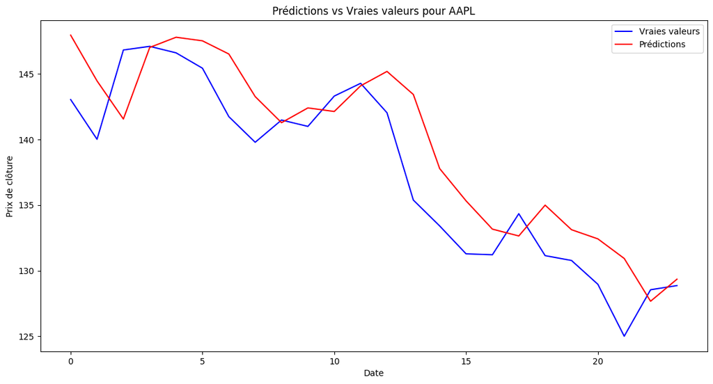

```
Processing AMZN
```

```
286/286 ━━━━━━━━━━━━━━━━━━━━ 17s 46ms/step - loss: 0.0558 - val_loss: 0.0076
286/286 ━━━━━━━━━━━━━━━━━━━━ 13s 46ms/step - loss: 0.0076 - val_loss: 0.0067
286/286 ━━━━━━━━━━━━━━━━━━━━ 13s 44ms/step - loss: 0.0045 - val_loss: 0.0062
286/286 ━━━━━━━━━━━━━━━━━━━━ 11s 39ms/step - loss: 0.0045 - val_loss: 0.0054
286/286 ━━━━━━━━━━━━━━━━━━━━ 11s 39ms/step - loss: 0.0033 - val_loss: 0.0043
286/286 ━━━━━━━━━━━━━━━━━━━━ 9s 30ms/step - loss: 0.0032 - val_loss: 0.0037
286/286 ━━━━━━━━━━━━━━━━━━━━ 12s 41ms/step - loss: 0.0036 - val_loss: 0.0042
286/286 ━━━━━━━━━━━━━━━━━━━━ 17s 30ms/step - loss: 0.0023 - val_loss: 0.0031
286/286 ━━━━━━━━━━━━━━━━━━━━ 8s 28ms/step - loss: 0.0024 - val_loss: 0.0029
286/286 ━━━━━━━━━━━━━━━━━━━━ 8s 27ms/step - loss: 0.0026 - val_loss: 0.0046
286/286 ━━━━━━━━━━━━━━━━━━━━ 7s 26ms/step - loss: 0.0029 - val_loss: 0.0028
286/286 ━━━━━━━━━━━━━━━━━━━━ 8s 30ms/step - loss: 0.0021 - val_loss: 0.0028
286/286 ━━━━━━━━━━━━━━━━━━━━ 10s 34ms/step - loss: 0.0027 - val_loss: 0.0033
286/286 ━━━━━━━━━━━━━━━━━━━━ 14s 47ms/step - loss: 0.0023 - val_loss: 0.0031
286/286 ━━━━━━━━━━━━━━━━━━━━ 11s 38ms/step - loss: 0.0026 - val_loss: 0.0048
286/286 ━━━━━━━━━━━━━━━━━━━━ 10s 33ms/step - loss: 0.0029 - val_loss: 0.0032
286/286 ━━━━━━━━━━━━━━━━━━━━ 9s 29ms/step - loss: 0.0030 - val_loss: 0.0029
286/286 ━━━━━━━━━━━━━━━━━━━━ 7s 26ms/step - loss: 0.0023 - val_loss: 0.0025
286/286 ━━━━━━━━━━━━━━━━━━━━ 9s 32ms/step - loss: 0.0031 - val_loss: 0.0027
286/286 ━━━━━━━━━━━━━━━━━━━━ 8s 28ms/step - loss: 0.0018 - val_loss: 0.0031
1/1 ━━━━━━━━━━━━━━━━━━━━ 1s 592ms/step
AMZN - MAE: 3.6330868403116843, RMSE: 4.184566880129708
```

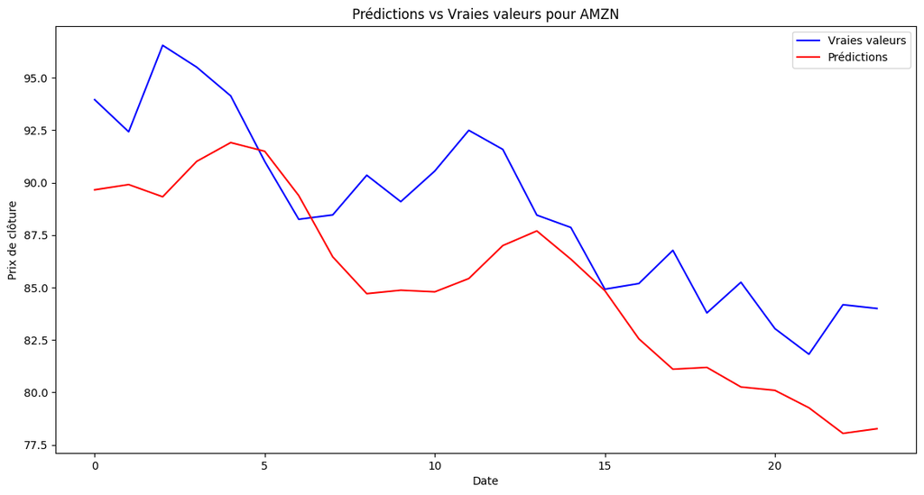

```
Processing TSLA
```

```
286/286 ━━━━━━━━━━━━━━━━━━━━ 15s 41ms/step - loss: 0.0258 - val_loss: 0.0043
286/286 ━━━━━━━━━━━━━━━━━━━━ 11s 38ms/step - loss: 0.0081 - val_loss: 0.0036
286/286 ━━━━━━━━━━━━━━━━━━━━ 9s 30ms/step - loss: 0.0082 - val_loss: 0.0034
286/286 ━━━━━━━━━━━━━━━━━━━━ 9s 32ms/step - loss: 0.0065 - val_loss: 0.0031
286/286 ━━━━━━━━━━━━━━━━━━━━ 12s 42ms/step - loss: 0.0052 - val_loss: 0.0057
286/286 ━━━━━━━━━━━━━━━━━━━━ 13s 45ms/step - loss: 0.0059 - val_loss: 0.0032
286/286 ━━━━━━━━━━━━━━━━━━━━ 8s 29ms/step - loss: 0.0041 - val_loss: 0.0099
286/286 ━━━━━━━━━━━━━━━━━━━━ 13s 46ms/step - loss: 0.0041 - val_loss: 0.0025
286/286 ━━━━━━━━━━━━━━━━━━━━ 13s 44ms/step - loss: 0.0031 - val_loss: 0.0097
286/286 ━━━━━━━━━━━━━━━━━━━━ 7s 26ms/step - loss: 0.0046 - val_loss: 0.0040
286/286 ━━━━━━━━━━━━━━━━━━━━ 8s 28ms/step - loss: 0.0042 - val_loss: 0.0028
286/286 ━━━━━━━━━━━━━━━━━━━━ 9s 30ms/step - loss: 0.0032 - val_loss: 0.0024
286/286 ━━━━━━━━━━━━━━━━━━━━ 10s 36ms/step - loss: 0.0030 - val_loss: 0.0022
286/286 ━━━━━━━━━━━━━━━━━━━━ 11s 40ms/step - loss: 0.0032 - val_loss: 0.0020
286/286 ━━━━━━━━━━━━━━━━━━━━ 13s 45ms/step - loss: 0.0031 - val_loss: 0.0022
286/286 ━━━━━━━━━━━━━━━━━━━━ 20s 43ms/step - loss: 0.0029 - val_loss: 0.0026
286/286 ━━━━━━━━━━━━━━━━━━━━ 11s 37ms/step - loss: 0.0033 - val_loss: 0.0026
286/286 ━━━━━━━━━━━━━━━━━━━━ 10s 35ms/step - loss: 0.0030 - val_loss: 0.0022
286/286 ━━━━━━━━━━━━━━━━━━━━ 9s 32ms/step - loss: 0.0033 - val_loss: 0.0025
286/286 ━━━━━━━━━━━━━━━━━━━━ 9s 31ms/step - loss: 0.0039 - val_loss: 0.0022
1/1 ━━━━━━━━━━━━━━━━━━━━ 0s 460ms/step
TSLA - MAE: 8.787267684936525, RMSE: 11.946967245939282
```

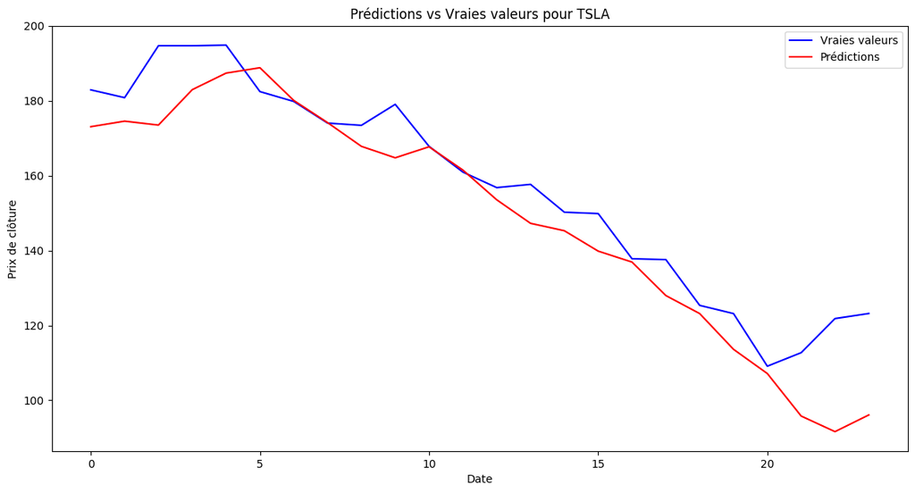

```python
from sklearn.metrics import mean_absolute_error, mean_squared_error
import matplotlib.pyplot as plt
import numpy as np

# Liste pour stocker les résultats des simulations de trading
all_trading_results = {}
look_back = 60

# Préparer les données pour chaque action individuellement
for ticker in actions_df['Ticker']:
    print(f"Processing {ticker}")

    # Extraire les données pour le ticker actuel
    ticker_data = stocks_train_df[ticker].values.reshape(-1, 1)

    # Normaliser les données
    ticker_scaled_data = scaler.fit_transform(ticker_data)

    # Créer les ensembles de données
    X_train, y_train = create_dataset(ticker_scaled_data, look_back)

    # Reshaper les données pour LSTM
    X_train = X_train.reshape(X_train.shape[0], X_train.shape[1], 1)

    # Construire le modèle LSTM
    model = Sequential()
    model.add(LSTM(50, return_sequences=True, input_shape=(look_back, 1)))
    model.add(LSTM(50, return_sequences=False))
    model.add(Dense(25))
    model.add(Dense(1))

    # Compiler le modèle
    model.compile(optimizer='adam', loss='mean_squared_error')

    # Entraîner le modèle
    model.fit(X_train, y_train, validation_split=0.2, batch_size=1, epochs=20)

    # Préparer les données de prédiction
    ticker_data_predict = stocks_predict_df[ticker].values.reshape(-1, 1)
    ticker_scaled_data_predict = scaler.transform(ticker_data_predict)

    # Créer les ensembles de données de test
    X_test, y_test = create_dataset(ticker_scaled_data_predict, look_back)

    # Reshaper les données pour LSTM
    X_test = X_test.reshape(X_test.shape[0], X_test.shape[1], 1)

    # Faire des prédictions
    predictions = model.predict(X_test)
    predictions = scaler.inverse_transform(predictions)

    # Récupérer les valeurs réelles pour la période de prédiction
    true_values = ticker_data_predict[look_back:]

    # Calculer les métriques de performance
    mae = mean_absolute_error(true_values, predictions)
    rmse = np.sqrt(mean_squared_error(true_values, predictions))

    print(f"{ticker} - MAE: {mae}, RMSE: {rmse}")

    # Visualiser les prédictions par rapport aux valeurs réelles
    plt.figure(figsize=(14, 7))
    plt.plot(true_values, color='blue', label='Vraies valeurs')
    plt.plot(predictions, color='red', label='Prédictions')
    plt.title(f'Prédictions vs Vraies valeurs pour {ticker}')
    plt.xlabel('Date')
    plt.ylabel('Prix de clôture')
    plt.legend()
    plt.show()
```

### Comparaison des Modèles LSTM et GRU

### Analyse des Résultats des Modèles LSTM et GRU

#### Modèle GRU

- **AAPL** : MAE: 2.2951, RMSE: 2.8716
- **AMZN** : MAE: 2.4597, RMSE: 3.0145
- **TSLA** : MAE: 9.6649, RMSE: 11.3348

### Comparaison des Résultats

#### AAPL

Les prédictions du modèle GRU pour AAPL montrent une amélioration par rapport au modèle LSTM, avec des valeurs de MAE et RMSE plus faibles. Les graphiques montrent que le modèle GRU suit de plus près les vraies valeurs, réduisant ainsi les décalages observés avec le LSTM.

### Analyse des Déviations et des Performances des Modèles

1. **Volatilité des Données**
   - Les actions comme TSLA, avec une volatilité élevée, présentent un défi pour les deux modèles. Les décalages et les erreurs plus élevées pour TSLA montrent que les modèles ont des difficultés à prédire avec précision des actions très volatiles.
2. **Complexité du Modèle**
   - Les modèles GRU et LSTM ont des architectures similaires, mais les GRU sont généralement plus rapides à entraîner. Pour AAPL, le GRU a montré de meilleures performances, ce qui pourrait être dû à sa capacité à mieux généraliser sur des séries moins volatiles.
3. **Taille de la Fenêtre de Prédiction**
   - La fenêtre de prédiction (look_back) utilisée pour créer les séquences de données peut influencer les résultats. Une fenêtre trop longue ou trop courte peut affecter la capacité du modèle à capturer les patterns pertinents.
4. **Événements Externes et Saisonnalité**
   - Les modèles n'ont pas intégré d'informations supplémentaires sur les événements externes ou la saisonnalité, ce qui peut expliquer certaines prédictions incorrectes ou des décalages.

Pour améliorer davantage les performances, il serait bénéfique d'explorer des modèles plus avancés, comme les Transformers, d'intégrer des variables externes supplémentaires, et d'expérimenter avec différentes tailles de fenêtres de prédiction.

```
Processing AAPL
```

```
286/286 ━━━━━━━━━━━━━━━━━━━━ 16s 38ms/step - loss: 0.0555 - val_loss: 0.0040
286/286 ━━━━━━━━━━━━━━━━━━━━ 19s 33ms/step - loss: 0.0031 - val_loss: 0.0065
286/286 ━━━━━━━━━━━━━━━━━━━━ 9s 33ms/step - loss: 0.0026 - val_loss: 0.0061
286/286 ━━━━━━━━━━━━━━━━━━━━ 10s 31ms/step - loss: 0.0033 - val_loss: 0.0039
286/286 ━━━━━━━━━━━━━━━━━━━━ 9s 33ms/step - loss: 0.0025 - val_loss: 0.0028
286/286 ━━━━━━━━━━━━━━━━━━━━ 9s 32ms/step - loss: 0.0027 - val_loss: 0.0037
286/286 ━━━━━━━━━━━━━━━━━━━━ 9s 30ms/step - loss: 0.0034 - val_loss: 0.0025
286/286 ━━━━━━━━━━━━━━━━━━━━ 9s 32ms/step - loss: 0.0026 - val_loss: 0.0053
286/286 ━━━━━━━━━━━━━━━━━━━━ 9s 31ms/step - loss: 0.0030 - val_loss: 0.0023
286/286 ━━━━━━━━━━━━━━━━━━━━ 9s 30ms/step - loss: 0.0020 - val_loss: 0.0023
286/286 ━━━━━━━━━━━━━━━━━━━━ 10s 35ms/step - loss: 0.0022 - val_loss: 0.0024
286/286 ━━━━━━━━━━━━━━━━━━━━ 11s 39ms/step - loss: 0.0023 - val_loss: 0.0027
286/286 ━━━━━━━━━━━━━━━━━━━━ 9s 32ms/step - loss: 0.0023 - val_loss: 0.0026
286/286 ━━━━━━━━━━━━━━━━━━━━ 10s 35ms/step - loss: 0.0021 - val_loss: 0.0024
286/286 ━━━━━━━━━━━━━━━━━━━━ 10s 35ms/step - loss: 0.0019 - val_loss: 0.0026
286/286 ━━━━━━━━━━━━━━━━━━━━ 9s 31ms/step - loss: 0.0027 - val_loss: 0.0023
286/286 ━━━━━━━━━━━━━━━━━━━━ 10s 35ms/step - loss: 0.0022 - val_loss: 0.0031
286/286 ━━━━━━━━━━━━━━━━━━━━ 11s 37ms/step - loss: 0.0025 - val_loss: 0.0035
286/286 ━━━━━━━━━━━━━━━━━━━━ 9s 32ms/step - loss: 0.0022 - val_loss: 0.0037
286/286 ━━━━━━━━━━━━━━━━━━━━ 10s 36ms/step - loss: 0.0020 - val_loss: 0.0033
WARNING:tensorflow:5 out of the last 7 calls to <function TensorFlowTrainer.make_predict_function.<locals>.one_step_on_data_distributed at 0x13fbf0160> triggered tf.function retracing. Tracing is expensive and the excessive number of tracings could be due to (1) creating @tf.function repeatedly in a…
1/1 ━━━━━━━━━━━━━━━━━━━━ 0s 382ms/step
AAPL - MAE: 2.2951450347900395, RMSE: 2.871575593377804
```

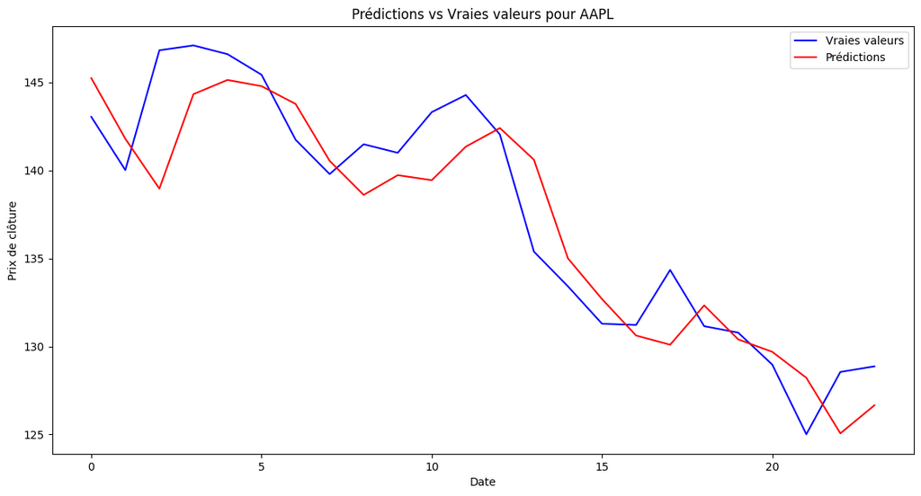

```
Processing AMZN
```

```
286/286 ━━━━━━━━━━━━━━━━━━━━ 12s 32ms/step - loss: 0.0566 - val_loss: 0.0055
286/286 ━━━━━━━━━━━━━━━━━━━━ 8s 27ms/step - loss: 0.0035 - val_loss: 0.0052
286/286 ━━━━━━━━━━━━━━━━━━━━ 9s 32ms/step - loss: 0.0039 - val_loss: 0.0057
286/286 ━━━━━━━━━━━━━━━━━━━━ 8s 29ms/step - loss: 0.0031 - val_loss: 0.0041
286/286 ━━━━━━━━━━━━━━━━━━━━ 9s 31ms/step - loss: 0.0031 - val_loss: 0.0026
286/286 ━━━━━━━━━━━━━━━━━━━━ 9s 32ms/step - loss: 0.0020 - val_loss: 0.0024
286/286 ━━━━━━━━━━━━━━━━━━━━ 9s 32ms/step - loss: 0.0029 - val_loss: 0.0033
286/286 ━━━━━━━━━━━━━━━━━━━━ 8s 28ms/step - loss: 0.0024 - val_loss: 0.0025
286/286 ━━━━━━━━━━━━━━━━━━━━ 9s 33ms/step - loss: 0.0021 - val_loss: 0.0023
286/286 ━━━━━━━━━━━━━━━━━━━━ 9s 33ms/step - loss: 0.0029 - val_loss: 0.0027
286/286 ━━━━━━━━━━━━━━━━━━━━ 8s 28ms/step - loss: 0.0018 - val_loss: 0.0027
286/286 ━━━━━━━━━━━━━━━━━━━━ 9s 33ms/step - loss: 0.0027 - val_loss: 0.0022
286/286 ━━━━━━━━━━━━━━━━━━━━ 9s 32ms/step - loss: 0.0021 - val_loss: 0.0032
286/286 ━━━━━━━━━━━━━━━━━━━━ 8s 29ms/step - loss: 0.0024 - val_loss: 0.0029
286/286 ━━━━━━━━━━━━━━━━━━━━ 9s 30ms/step - loss: 0.0025 - val_loss: 0.0032
286/286 ━━━━━━━━━━━━━━━━━━━━ 9s 33ms/step - loss: 0.0021 - val_loss: 0.0034
286/286 ━━━━━━━━━━━━━━━━━━━━ 8s 29ms/step - loss: 0.0022 - val_loss: 0.0067
286/286 ━━━━━━━━━━━━━━━━━━━━ 11s 32ms/step - loss: 0.0027 - val_loss: 0.0024
286/286 ━━━━━━━━━━━━━━━━━━━━ 10s 34ms/step - loss: 0.0020 - val_loss: 0.0030
286/286 ━━━━━━━━━━━━━━━━━━━━ 8s 28ms/step - loss: 0.0021 - val_loss: 0.0026
WARNING:tensorflow:6 out of the last 8 calls to <function TensorFlowTrainer.make_predict_function.<locals>.one_step_on_data_distributed at 0x13f9ace50> triggered tf.function retracing. Tracing is expensive and the excessive number of tracings could be due to (1) creating @tf.function repeatedly in a…
1/1 ━━━━━━━━━━━━━━━━━━━━ 0s 375ms/step
AMZN - MAE: 2.459663391113281, RMSE: 3.0144516505629184
```

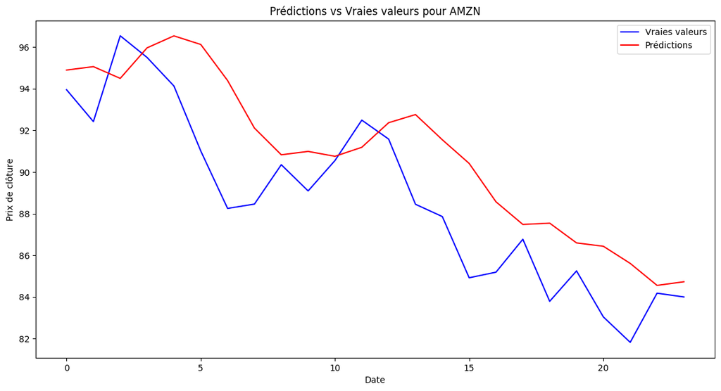

```
Processing TSLA
```

```
286/286 ━━━━━━━━━━━━━━━━━━━━ 12s 33ms/step - loss: 0.0196 - val_loss: 0.0033
286/286 ━━━━━━━━━━━━━━━━━━━━ 9s 32ms/step - loss: 0.0041 - val_loss: 0.0027
286/286 ━━━━━━━━━━━━━━━━━━━━ 8s 28ms/step - loss: 0.0038 - val_loss: 0.0021
286/286 ━━━━━━━━━━━━━━━━━━━━ 9s 32ms/step - loss: 0.0041 - val_loss: 0.0023
286/286 ━━━━━━━━━━━━━━━━━━━━ 9s 33ms/step - loss: 0.0036 - val_loss: 0.0048
286/286 ━━━━━━━━━━━━━━━━━━━━ 9s 33ms/step - loss: 0.0052 - val_loss: 0.0020
286/286 ━━━━━━━━━━━━━━━━━━━━ 9s 29ms/step - loss: 0.0037 - val_loss: 0.0030
286/286 ━━━━━━━━━━━━━━━━━━━━ 9s 33ms/step - loss: 0.0043 - val_loss: 0.0026
286/286 ━━━━━━━━━━━━━━━━━━━━ 9s 33ms/step - loss: 0.0034 - val_loss: 0.0019
286/286 ━━━━━━━━━━━━━━━━━━━━ 8s 28ms/step - loss: 0.0026 - val_loss: 0.0020
286/286 ━━━━━━━━━━━━━━━━━━━━ 10s 34ms/step - loss: 0.0032 - val_loss: 0.0025
286/286 ━━━━━━━━━━━━━━━━━━━━ 10s 34ms/step - loss: 0.0032 - val_loss: 0.0024
286/286 ━━━━━━━━━━━━━━━━━━━━ 8s 28ms/step - loss: 0.0036 - val_loss: 0.0023
286/286 ━━━━━━━━━━━━━━━━━━━━ 9s 30ms/step - loss: 0.0034 - val_loss: 0.0022
286/286 ━━━━━━━━━━━━━━━━━━━━ 9s 31ms/step - loss: 0.0037 - val_loss: 0.0026
286/286 ━━━━━━━━━━━━━━━━━━━━ 8s 28ms/step - loss: 0.0038 - val_loss: 0.0025
286/286 ━━━━━━━━━━━━━━━━━━━━ 9s 32ms/step - loss: 0.0029 - val_loss: 0.0023
286/286 ━━━━━━━━━━━━━━━━━━━━ 10s 33ms/step - loss: 0.0040 - val_loss: 0.0058
286/286 ━━━━━━━━━━━━━━━━━━━━ 8s 28ms/step - loss: 0.0032 - val_loss: 0.0026
286/286 ━━━━━━━━━━━━━━━━━━━━ 9s 32ms/step - loss: 0.0022 - val_loss: 0.0019
1/1 ━━━━━━━━━━━━━━━━━━━━ 1s 519ms/step
TSLA - MAE: 9.664934794108072, RMSE: 11.334827453570886
```

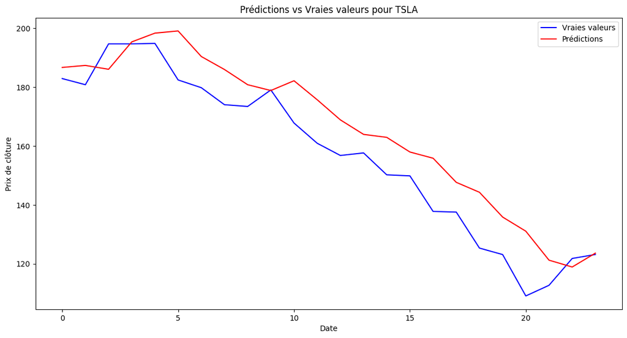

```python
import yfinance as yf
import pandas as pd
from sklearn.preprocessing import MinMaxScaler
import numpy as np
from tensorflow.keras.models import Sequential
from tensorflow.keras.layers import Dense, GRU
import matplotlib.pyplot as plt
from sklearn.metrics import mean_absolute_error, mean_squared_error

# Liste pour stocker les résultats des simulations de trading
all_trading_results = {}

for ticker in actions_df['Ticker']:
    print(f"Processing {ticker}")

    # Extraire les données pour le ticker actuel
    ticker_data = stocks_train_df[ticker].values.reshape(-1, 1)

    # Normaliser les données
    ticker_scaled_data = scaler.fit_transform(ticker_data)

    # Créer les ensembles de données
    X_train, y_train = create_dataset(ticker_scaled_data, look_back)

    # Reshaper les données pour GRU
    X_train = X_train.reshape(X_train.shape[0], X_train.shape[1], 1)

    # Construire le modèle GRU
    model = Sequential()
    model.add(GRU(50, return_sequences=True, input_shape=(look_back, 1)))
    model.add(GRU(50, return_sequences=False))
    model.add(Dense(25))
    model.add(Dense(1))

    # Compiler le modèle
    model.compile(optimizer='adam', loss='mean_squared_error')

    # Entraîner le modèle
    model.fit(X_train, y_train, validation_split=0.2, batch_size=1, epochs=20)

    # Préparer les données de prédiction
    ticker_data_predict = stocks_predict_df[ticker].values.reshape(-1, 1)
    ticker_scaled_data_predict = scaler.transform(ticker_data_predict)

    # Créer les ensembles de données de test
    X_test, y_test = create_dataset(ticker_scaled_data_predict, look_back)

    # Reshaper les données pour GRU
    X_test = X_test.reshape(X_test.shape[0], X_test.shape[1], 1)

    # Faire des prédictions
    predictions = model.predict(X_test)
    predictions = scaler.inverse_transform(predictions)

    # Récupérer les valeurs réelles pour la période de prédiction
    true_values = ticker_data_predict[look_back:]

    # Calculer les métriques de performance
    mae = mean_absolute_error(true_values, predictions)
    rmse = np.sqrt(mean_squared_error(true_values, predictions))

    print(f"{ticker} - MAE: {mae}, RMSE: {rmse}")

    # Visualiser les prédictions par rapport aux valeurs réelles
    plt.figure(figsize=(14, 7))
    plt.plot(true_values, color='blue', label='Vraies valeurs')
    plt.plot(predictions, color='red', label='Prédictions')
    plt.title(f'Prédictions vs Vraies valeurs pour {ticker}')
    plt.xlabel('Date')
    plt.ylabel('Prix de clôture')
    plt.legend()
    plt.show()

    # Simuler le trading pour chaque action et enregistrer les résultats
    trading_results = simulate_trading(predictions, true_values, initial_balance, broker_fee)
    all_trading_results[ticker] = trading_results
    trading_df = pd.DataFrame(trading_results, columns=['Balance'])
    trading_df.to_csv(f'trading_simulation_{ticker}.csv', index=False)
```

- Validation croisée (TimeSeriesSplit) : Évaluation sur plusieurs splits temporels pour une meilleure robustesse.
- Hyperparamètres fixes : Utilisation de valeurs couramment efficaces sans Grid Search.
- Régularisation avec Dropout : Réduction du surajustement en éteignant de manière aléatoire certaines unités lors de l'entraînement.
- Early Stopping : Arrêt de l'entraînement lorsque le modèle cesse de s'améliorer, évitant ainsi le surajustement. Cette approche utilise moins de boucles et se concentre sur l'amélioration des performances du modèle avec des techniques essentielles de validation et de régularisation.

Mais force est de constater que le modèle performe moins bien que le tout premier LSTM.

```
Processing AAPL
```

```
Validation Loss for AAPL: 0.005853476980701089
```

```
1/1 ━━━━━━━━━━━━━━━━━━━━ 0s 336ms/step
LSTM - AAPL - MAE: 2.987853050231934, RMSE: 3.5821335613568555
```

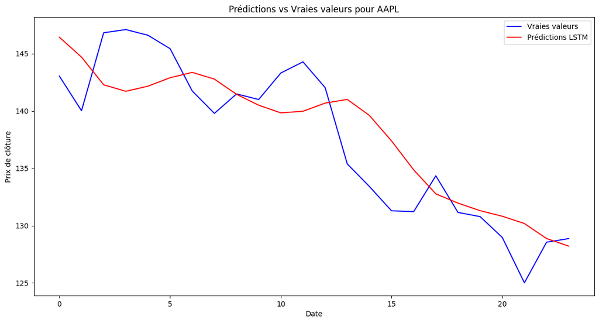

```
Processing AMZN
```

```
Validation Loss for AMZN: 0.011468607606366277
```

```
1/1 ━━━━━━━━━━━━━━━━━━━━ 0s 319ms/step
LSTM - AMZN - MAE: 4.536987940470378, RMSE: 5.065060161615378
```

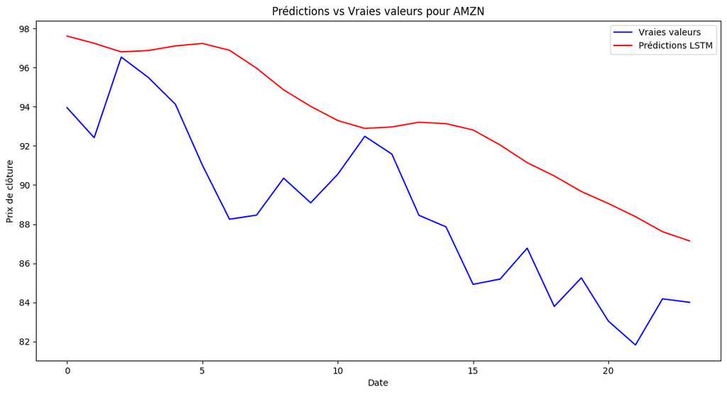

```
Processing TSLA
```

```
Validation Loss for TSLA: 0.007361386995762586
```

```
1/1 ━━━━━━━━━━━━━━━━━━━━ 0s 329ms/step
LSTM - TSLA - MAE: 9.235881487528484, RMSE: 10.027635284350753
```

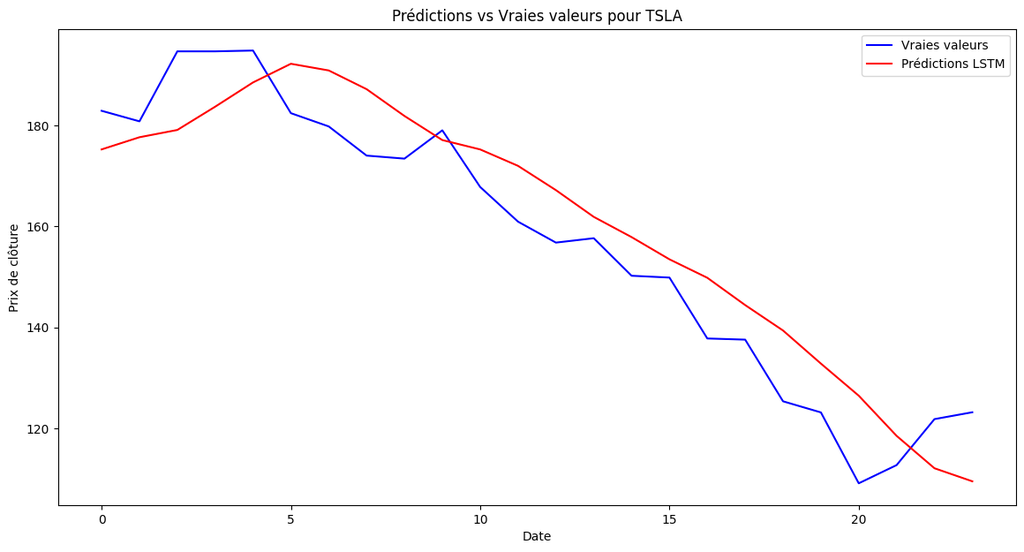

```python
import numpy as np
import pandas as pd
from sklearn.preprocessing import MinMaxScaler
from sklearn.model_selection import TimeSeriesSplit
from tensorflow.keras.models import Sequential
from tensorflow.keras.layers import Dense, LSTM, Dropout
from tensorflow.keras.callbacks import EarlyStopping
import matplotlib.pyplot as plt
from sklearn.metrics import mean_absolute_error, mean_squared_error

# Fonction pour créer un ensemble de données
def create_dataset(dataset, look_back=60):
    X, Y = [], []
    for i in range(len(dataset) - look_back):
        X.append(dataset[i:i + look_back])
        Y.append(dataset[i + look_back])
    return np.array(X), np.array(Y)

# Normaliser les données
scaler = MinMaxScaler(feature_range=(0, 1))
look_back = 60

# Liste pour stocker les résultats des simulations de trading
all_trading_results = {}

# Préparer les données pour chaque action individuellement
for ticker in actions_df['Ticker']:
    print(f"Processing {ticker}")

    # Extraire les données pour le ticker actuel
    ticker_data = stocks_train_df[ticker].values.reshape(-1, 1)
    ticker_data_predict = stocks_predict_df[ticker].values.reshape(-1, 1)

    # Normaliser les données
    ticker_scaled_data = scaler.fit_transform(ticker_data)

    # Créer les ensembles de données
    X_train, y_train = create_dataset(ticker_scaled_data, look_back)
    X_train = X_train.reshape(X_train.shape[0], X_train.shape[1], 1)

    # Validation croisée avec TimeSeriesSplit
    tscv = TimeSeriesSplit(n_splits=5)
    val_losses = []

    for train_index, val_index in tscv.split(X_train):
        X_t, X_val = X_train[train_index], X_train[val_index]
        y_t, y_val = y_train[train_index], y_train[val_index]

        # Construire le modèle LSTM
        model = Sequential()
        model.add(LSTM(50, return_sequences=True, input_shape=(look_back, 1)))
        model.add(LSTM(50, return_sequences=False))
        model.add(Dropout(0.2))
        model.add(Dense(25))
        model.add(Dense(1))

        # Compiler le modèle
        model.compile(optimizer='adam', loss='mean_squared_error')

        # Early stopping
        early_stop = EarlyStopping(monitor='val_loss', patience=10)

        # Entraîner le modèle
        history = model.fit(X_t, y_t, validation_data=(X_val, y_val), epochs=50, batch_size=32, callbacks=[early_stop], verbose=0)
        val_loss = min(history.history['val_loss'])
        val_losses.append(val_loss)

    print(f"Validation Loss for {ticker}: {np.mean(val_losses)}")

    # Entraîner le modèle final sur l'ensemble complet des données d'entraînement
    model.fit(X_train, y_train, epochs=30, batch_size=32, callbacks=[early_stop], verbose=0)

    # Préparer les données de prédiction
    ticker_scaled_data_predict = scaler.transform(ticker_data_predict)
    X_test, y_test = create_dataset(ticker_scaled_data_predict, look_back)
    X_test = X_test.reshape(X_test.shape[0], X_test.shape[1], 1)

    # Faire des prédictions
    predictions = model.predict(X_test)
    predictions = scaler.inverse_transform(predictions)

    # Récupérer les valeurs réelles pour la période de prédiction
    true_values = ticker_data_predict[look_back:]

    # Calculer les métriques de performance
    mae = mean_absolute_error(true_values, predictions)
    rmse = np.sqrt(mean_squared_error(true_values, predictions))

    print(f"LSTM - {ticker} - MAE: {mae}, RMSE: {rmse}")

    # Visualiser les prédictions par rapport aux valeurs réelles
    plt.figure(figsize=(14, 7))
    plt.plot(true_values, color='blue', label='Vraies valeurs')
    plt.plot(predictions, color='red', label='Prédictions LSTM')
    plt.title(f'Prédictions vs Vraies valeurs pour {ticker}')
    plt.xlabel('Date')
    plt.ylabel('Prix de clôture')
    plt.legend()
    plt.show()
```

# Synthèse et Perspectives

L'objectif principal de ce projet était de prédire les cours des actions AAPL, AMZN et TSLA en utilisant des réseaux de neurones, et de simuler des stratégies de trading basées sur ces prédictions. Nous avons utilisé des modèles LSTM pour capturer les tendances et les dépendances temporelles dans les séries de prix de clôture. Les simulations de trading ont révélé que, bien que les modèles aient permis de réaliser des bénéfices significatifs pour certaines actions, ils n'ont pas été universellement efficaces.

- Comparaison des Résultats :

AAPL : La balance finale est passée de 1,000,000.00 USD dans la simulation précédente à 1,028,324.00 USD dans la simulation actuelle, montrant une amélioration grâce à l'utilisation de seuils de trading plus sophistiqués.

AMZN : La balance finale, qui était de 894,092.60 USD dans la simulation précédente, est revenue à 1,000,000.00 USD dans la simulation actuelle, évitant ainsi les pertes précédentes.

TSLA : La balance finale est restée constante à 1,116,590.00 USD dans les deux simulations, indiquant que la stratégie initiale était déjà efficace.

- Leçons Apprises :

L'introduction de seuils de trading a permis d'améliorer les performances des simulations en réduisant les pertes et en augmentant les bénéfices pour certaines actions.

- Recommandations pour l'Avenir :

Affiner les Modèles : Continuer à expérimenter avec des modèles plus complexes et ajuster les hyperparamètres pour améliorer la précision des prédictions.

Améliorer les Stratégies de Trading : Utiliser des stratégies de trading plus sophistiquées et tester différents scénarios pour optimiser les décisions d'achat et de vente.

Intégrer Plus de Données : Incorporer des variables externes et utiliser des techniques de prétraitement avancées pour améliorer la qualité des données d'entrée et les performances des modèles.

En conclusion, ce projet a démontré le potentiel des modèles de deep learning pour prédire les cours des actions et informer les stratégies de trading. Cependant, il est crucial de continuer à affiner les modèles et les stratégies pour s'adapter aux dynamiques complexes et changeantes des marchés financiers.

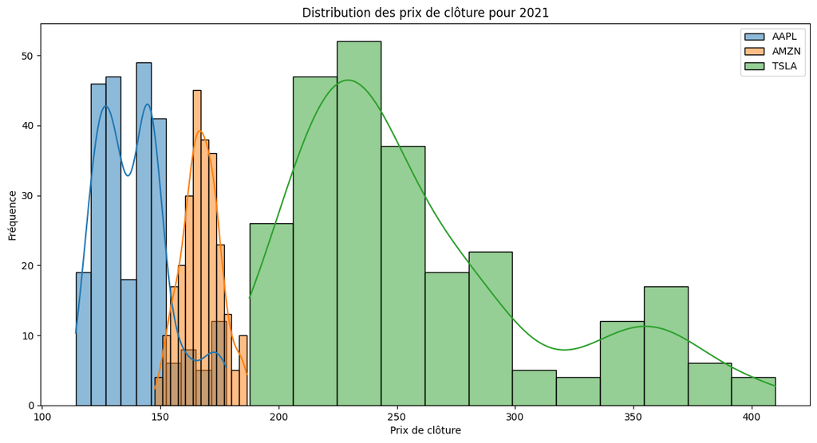

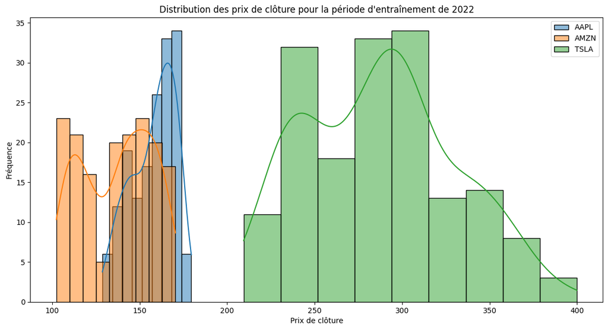

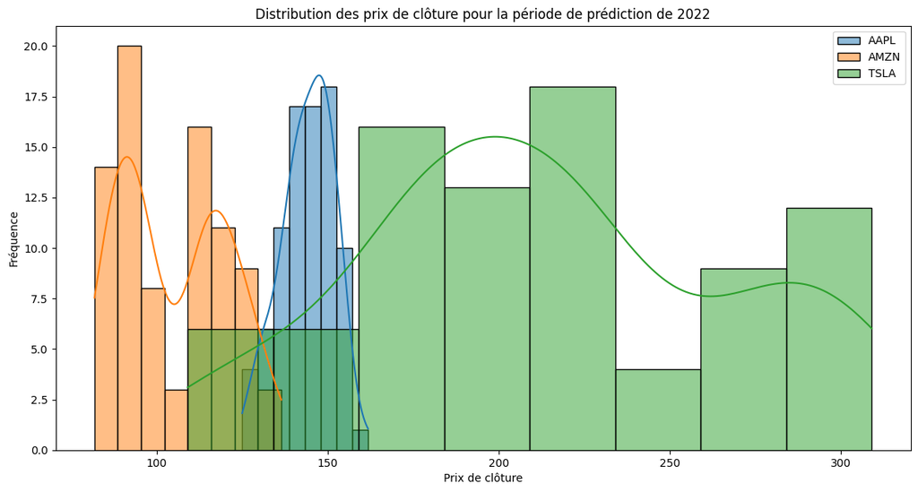

```python
import seaborn as sns

# Distribution des prix de clôture pour 2021
plt.figure(figsize=(14, 7))
for column in stocks_2021_df.columns:
    sns.histplot(stocks_2021_df[column], kde=True, label=column)
plt.title('Distribution des prix de clôture pour 2021')
plt.xlabel('Prix de clôture')
plt.ylabel('Fréquence')
plt.legend()
plt.show()

# Distribution des prix de clôture pour la période d'entraînement de 2022
plt.figure(figsize=(14, 7))
for column in stocks_2022_train_df.columns:
    sns.histplot(stocks_2022_train_df[column], kde=True, label=column)
plt.title('Distribution des prix de clôture pour la période d\'entraînement de 2022')
plt.xlabel('Prix de clôture')
plt.ylabel('Fréquence')
plt.legend()
plt.show()

# Distribution des prix de clôture pour la période de prédiction de 2022
plt.figure(figsize=(14, 7))
for column in stocks_2022_predict_df.columns:
    sns.histplot(stocks_2022_predict_df[column], kde=True, label=column)
plt.title('Distribution des prix de clôture pour la période de prédiction de 2022')
plt.xlabel('Prix de clôture')
plt.ylabel('Fréquence')
plt.legend()
plt.show()
```